# Отчет по второму заданию практикума

## Основные положения разведывательного анализа данных

Разведывательный анализ данных направлен на выявление основных характеристик и суммирование их с целью построения некоторых гипотез. Для удобства чаще всего используют визуализацию, по которой достаточно просто построить гипотезы.

## Этапы анализа

### Первый этап - анализ первичных данных

Рассмотрим данные по производству:

```r
  productionData <- read.csv('production-data.csv')
  productionDataHarpy <- subset(productionData, productionData$supplier == 'harpy.co')
  productionDataWesteros <- subset(productionData, productionData$supplier != 'harpy.co')
```

Harpy:

```r
  head(productionDataHarpy)
```

```
##   unsullen.id production.date report.date produced defects supplier
## 1           1               1           1      103       0 harpy.co
## 2           1               1           2        0       2 harpy.co
## 3           1               1           3        0       4 harpy.co
## 4           1               1           4        0       5 harpy.co
## 5           1               1           5        0      13 harpy.co
## 6           1               1           6        0      11 harpy.co
```

Westeros:

```r
  head(productionDataWesteros)
```

```
##      unsullen.id production.date report.date produced defects     supplier
## 1351          51               1           1      106       0 westeros.inc
## 1352          51               1           2        0       8 westeros.inc
## 1353          51               1           3        0       9 westeros.inc
## 1354          51               1           4        0       8 westeros.inc
## 1355          51               1           5        0      12 westeros.inc
## 1356          51               1           6        0       0 westeros.inc
```

Все дефекты распределены по партиям, произведенным каждым кузнецом. Рассмотрим распределение дефектов по каждому кузнецу на первый месяц после производства, на второй и так далее:

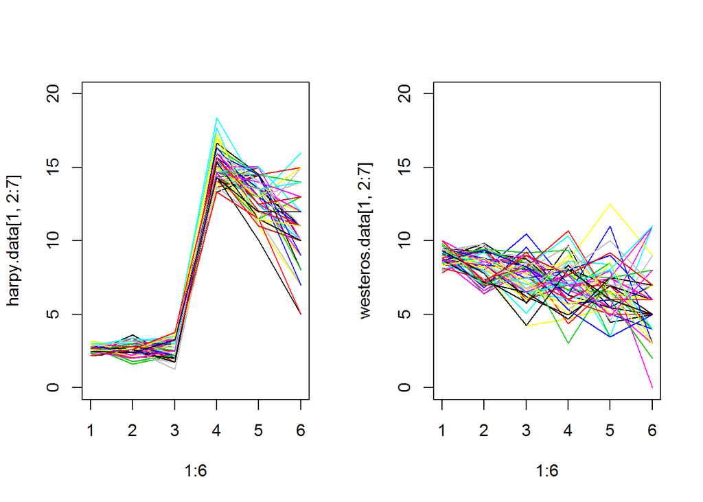

```r
harpy.id <- unique(productionDataHarpy$unsullen.id)
westeros.id <- unique(productionDataWesteros$unsullen.id)
harpy.data <- c()
westeros.data <- c()
for (i in 1:length(harpy.id)) {
  harpy.sub.data <- subset(productionDataHarpy, productionDataHarpy$unsullen.id == harpy.id[i])
  westeros.sub.data <- subset(productionDataWesteros, productionDataWesteros$unsullen.id == westeros.id[i])

  harpy.production <- harpy.sub.data$produced[harpy.sub.data$produced != 0]
  defects.one.day <- (subset(harpy.sub.data, harpy.sub.data$production.date == harpy.sub.data$report.date - 1))$defects
  defects.two.day <- (subset(harpy.sub.data, harpy.sub.data$production.date == harpy.sub.data$report.date - 2))$defects
  defects.three.day <- (subset(harpy.sub.data, harpy.sub.data$production.date == harpy.sub.data$report.date - 3))$defects
  defects.four.day <- (subset(harpy.sub.data, harpy.sub.data$production.date == harpy.sub.data$report.date - 4))$defects
  defects.five.day <- (subset(harpy.sub.data, harpy.sub.data$production.date == harpy.sub.data$report.date - 5))$defects
  defects.six.day <- (subset(harpy.sub.data, harpy.sub.data$production.date == harpy.sub.data$report.date - 6))$defects
  mean.one <- sum(defects.one.day * harpy.production) / sum(harpy.production)
  mean.two <- sum(defects.two.day * harpy.production[1:5]) / sum(harpy.production[1:5])
  mean.three <- sum(defects.three.day * harpy.production[1:4]) / sum(harpy.production[1:4])
  mean.four <- sum(defects.four.day * harpy.production[1:3]) / sum(harpy.production[1:3])
  mean.five <- sum(defects.five.day * harpy.production[1:2]) / sum(harpy.production[1:2])
  mean.six <- sum(defects.six.day * harpy.production[1:1]) / sum(harpy.production[1:1])
  harpy.data.id <- c(harpy.id[i], mean.one, mean.two, mean.three, mean.four, mean.five, mean.six)
  harpy.data <- rbind(harpy.data, harpy.data.id)

  westeros.production <- westeros.sub.data$produced[westeros.sub.data$produced != 0]
  defects.one.day <- (subset(westeros.sub.data, westeros.sub.data$production.date == westeros.sub.data$report.date - 1))$defects
  defects.two.day <- (subset(westeros.sub.data, westeros.sub.data$production.date == westeros.sub.data$report.date - 2))$defects
  defects.three.day <- (subset(westeros.sub.data, westeros.sub.data$production.date == westeros.sub.data$report.date - 3))$defects
  defects.four.day <- (subset(westeros.sub.data, westeros.sub.data$production.date == westeros.sub.data$report.date - 4))$defects
  defects.five.day <- (subset(westeros.sub.data, westeros.sub.data$production.date == westeros.sub.data$report.date - 5))$defects
  defects.six.day <- (subset(westeros.sub.data, westeros.sub.data$production.date == westeros.sub.data$report.date - 6))$defects
  mean.one <- sum(defects.one.day * westeros.production) / sum(westeros.production)
  mean.two <- sum(defects.two.day * westeros.production[1:5]) / sum(westeros.production[1:5])
  mean.three <- sum(defects.three.day * westeros.production[1:4]) / sum(westeros.production[1:4])
  mean.four <- sum(defects.four.day * westeros.production[1:3]) / sum(westeros.production[1:3])
  mean.five <- sum(defects.five.day * westeros.production[1:2]) / sum(westeros.production[1:2])
  mean.six <- sum(defects.six.day * westeros.production[1:1]) / sum(westeros.production[1:1])
  westeros.data.id <- c(westeros.id[i], mean.one, mean.two, mean.three, mean.four, mean.five, mean.six)
  westeros.data <- rbind(westeros.data, westeros.data.id)
}

rownames(harpy.data) <- c()
rownames(westeros.data) <- c()
colnames(harpy.data) <- c("id", paste0("mean.defect.", 1:6, "day"))
colnames(westeros.data) <- c("id", paste0("mean.defect.", 1:6, "day"))


par(mfrow=c(1,2))

plot(x = 1:6, y = harpy.data[1, 2:7], type = "l", ylim = c(0, 20))
for (i in 2:50) {
  lines(x = 1:6, y = harpy.data[i, 2:7], col = i)
}
plot(x = 1:6, y = westeros.data[1, 2:7], type = "l", ylim = c(0, 20))
for (i in 2:50) {
  lines(x = 1:6, y = westeros.data[i, 2:7], col = i)
}
```

Как видно из графиков harpy имеет большую дисперсию, а среднее имеет схожие черты с левой частью графика функции плотности нормального распределения.

График westeros имеет меньшую дисперсию, а среднее похоже на убывающую линейную функцию y = kx+b.

### Второй этап - оценки для анализа поставок стали каждой компанией

1. Построим график среднего для полученных выше распределений:

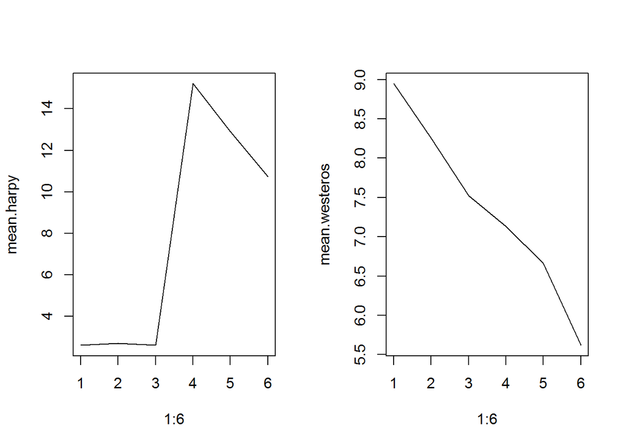

```r
mean.harpy <- c()
mean.westeros <- c()
for (i in 1:6) {
  mean.harpy[i] <- mean(harpy.data[, i + 1])
  mean.westeros[i] <- mean(westeros.data[, i + 1])
}

par(mfrow=c(1,2))
plot(x = 1:6, y = mean.harpy, type = "l")
plot(x = 1:6, y = mean.westeros, type = "l")
```

2. Добавим оценку математического ожидания для полученого выше среднего:

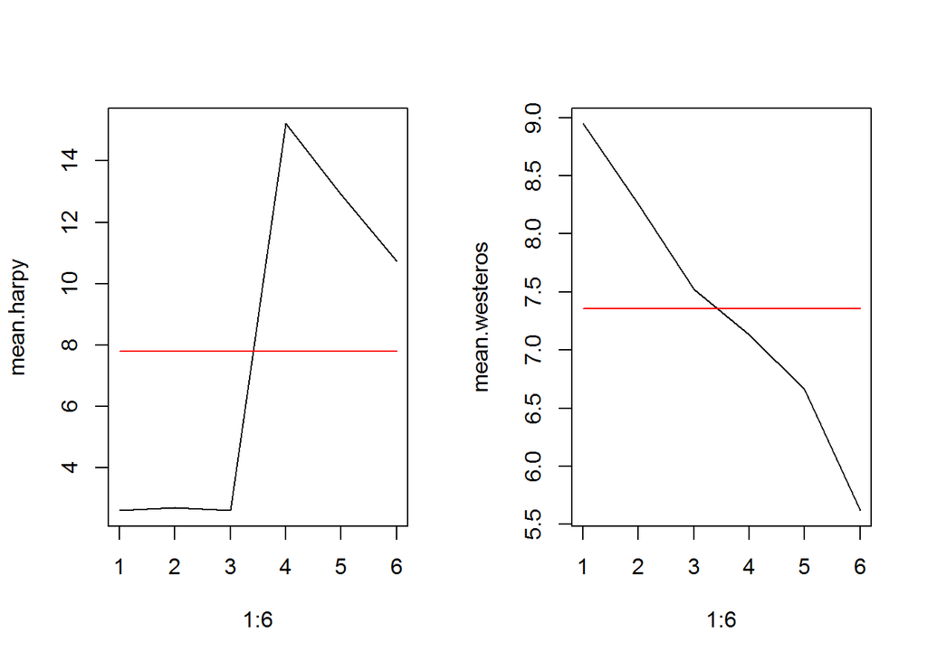

```r
par(mfrow=c(1,2))
plot(x = 1:6, y = mean.harpy, type = "l")
lines(x = 1:6, y = rep(mean(mean.harpy), 6), type = "l", col = "red")
plot(x = 1:6, y = mean.westeros, type = "l")
lines(x = 1:6, y = rep(mean(mean.westeros), 6), type = "l", col = "red")
```

Из графиков видно, что оценка математического ожидания дефектов для компании Harpy незначительно выше, чем для компании Westeros:

```r
mean(mean.harpy)
```

```
## [1] 7.791396
```

```r
mean(mean.westeros)
```

```
## [1] 7.357553
```

3. Рассмотрим в качестве оценки показатель “выборочная дисперсия”" - это оценка теоретической дисперсии распределения, рассчитанная на основе данных выборки. Для сохранения размерности, возьмем корень из дисперсии, то есть среднеквадратичное отклонение.

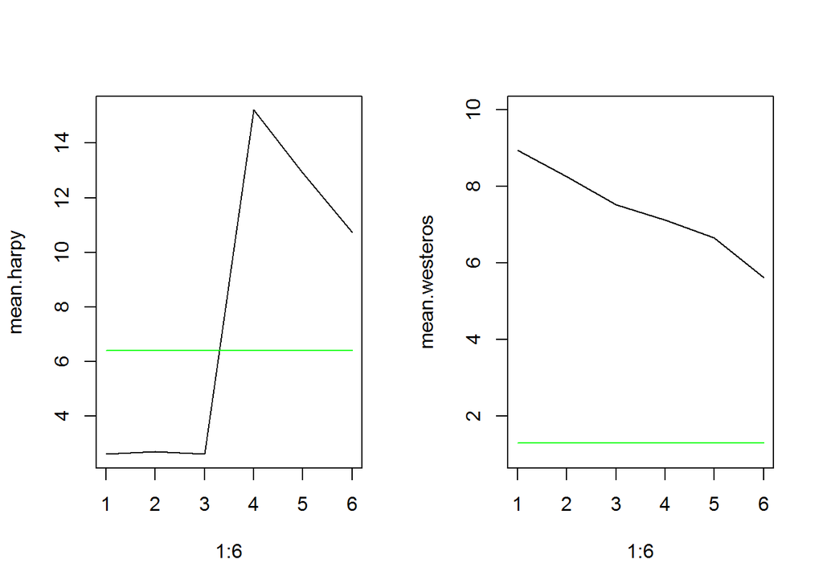

```r
par(mfrow=c(1,2))
plot(x = 1:6, y = mean.harpy, type = "l")
lines(x = 1:6, y = rep(sd(mean.harpy) * (6 / 5) ^ 0.5, 6), type = "l", col = "green")
plot(x = 1:6, y = mean.westeros, type = "l", ylim = c(1, 10))
lines(x = 1:6, y = rep(sd(mean.westeros) * (6 / 5) ^ 0.5, 6), type = "l", col = "green")
```

Из графиков видно, что оценка среднеквадратичного отклонения распределения дефектов для компании Harpy значительно выше, чем для компании Westeros:

```r
sd(mean.harpy) * (6 / 5) ^ 0.5
```

```
## [1] 6.385113
```

```r
sd(mean.westeros) * (6 / 5) ^ 0.5
```

```
## [1] 1.288848
```

4. Итоговым показателем рассмотрим коэффициент Шарпа:

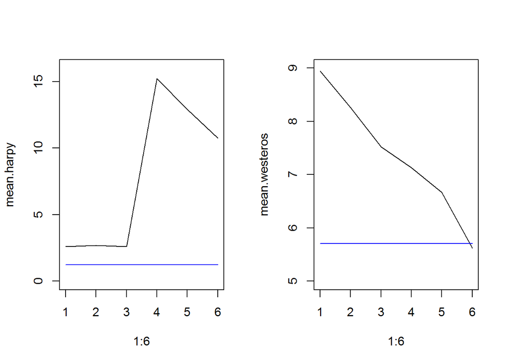

```r
par(mfrow=c(1,2))

plot(x = 1:6, y = mean.harpy, type = "l", ylim = c(0, 16))
lines(x = 1:6, y = rep(mean(mean.harpy) / (sd(mean.harpy) * (6 / 5) ^ 0.5), 6), type = "l", col = "blue")
plot(x = 1:6, y = mean.westeros, type = "l",ylim = c(5, 9))
lines(x = 1:6, y = rep(mean(mean.westeros) / (sd(mean.westeros) * (6 / 5) ^ 0.5), 6), type = "l", col = "blue")
```

Из графиков видно, что коэффициент Шарпа распределения дефектов для компании Harpy значительно ниже, чем для компании Westeros:

```r
mean(mean.harpy) / (sd(mean.harpy) * (6 / 5) ^ 0.5)
```

```
## [1] 1.220244
```

```r
mean(mean.westeros) / (sd(mean.westeros) * (6 / 5) ^ 0.5)
```

```
## [1] 5.708628
```

### Вывод

Таким образом, компания Westeros лидирует по всем трем оценкам, причем столь большая разница по оценке среднеквадратичного отклонения и коэффициенту Шарпа с довольно большой вероятностью не приблизится к 0 за 11 месяцев. Поэтому по результатам разведывательного анализа следует выбрать компанию Westeros.